# Univariate Poisson Model

Petr Keil

March 2017

This brief lesson introduces the concept of **discrete distribution** (**probability mass function**) on the example of Poisson distribution. We will also do more likelihood stuff.

Optional functions for interactive plotting for those with R-studio:

```r
library(manipulate)

source("https://raw.githubusercontent.com/petrkeil/ML_and_Bayes_2017_iDiv/master/Univariate%20Poisson%20Model/plotting_poisson.r")
```

# 1 Poisson distribution

Poisson distribution is a simple model for discrete and **positive count data**.

$$p\left( x \right) = \frac{{e^{ - \lambda } \lambda ^x }}{{x!}}$$

Where $\lambda$ is the only parameter, which is also the mean of the distribution.

# 2 Simulating poisson data

Let’s explore the Poisson model a bit and simulate some data using `rpois()`:

```r
rpois(n=100, lambda=1)
```

```
##   [1] 0 2 1 4 0 2 0 1 0 0 2 0 0 0 0 2 2 0 0 4 0 2 2 1 0 1 0 0 0 1 2 1 2 1 1
##  [36] 0 1 0 1 0 1 1 1 0 1 2 0 1 2 0 1 0 1 3 1 1 1 1 1 0 1 1 1 2 0 0 1 0 0 2
##  [71] 1 3 0 0 1 0 0 1 1 2 2 0 2 4 1 1 2 2 3 0 3 0 3 0 0 1 0 5 2 0
```

Now try different values of $\lambda$.

We can plot the “empirical frequency histogram” for simulated data with 3 different values of parameter $\lambda$:

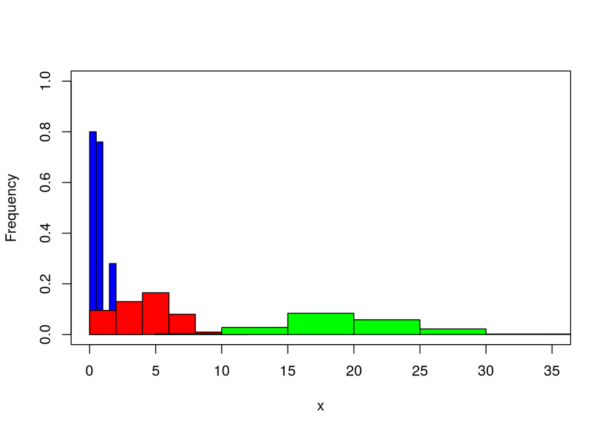

```r
  plot(c(0,35), c(0,1), type="n",
       xlab="x", ylab="Frequency")

  hist(rpois(n=100, lambda=1), add=T, freq=FALSE, col="blue")
  hist(rpois(n=100, lambda=5), add=T, freq=FALSE, col="red")
  hist(rpois(n=100, lambda=20), add=T, freq=FALSE, col="green")
```

Let’s plot the respective **probability mass functions**:

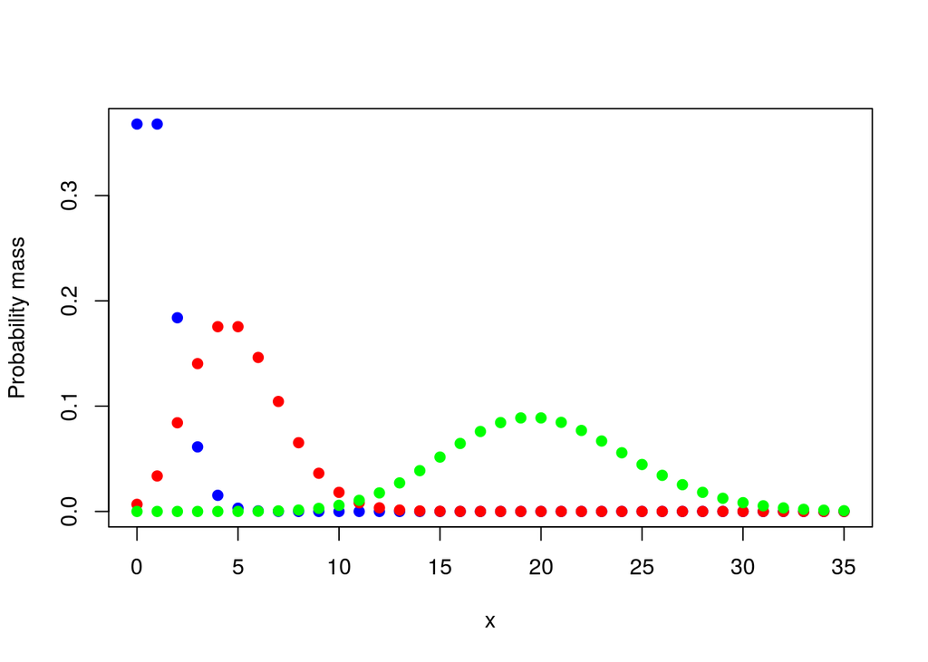

```r
  plot(0:35, dpois(0:35, lambda=1),
       col="blue", pch=19,
       ylab="Probability mass",
       xlab="x")
  points(0:35, dpois(0:35, lambda=5), col="red", pch=19)
  points(0:35, dpois(0:35, lambda=20), col="green", pch=19)
```

Interactive version

```r
manipulate(move.poisson(lambda),
           lambda=slider(1,100, step=0.01))
```

# 3 Poisson likelihood

I will generate the artificial data again:

```r
x <- rpois(n=100, lambda=8)
x
```

```
##   [1]  6  3 10  4 12  8  6 10 10  8  8 11 14 10  5  6 11 10  9  7  9  4  6
##  [24]  9  8  8  9  5  9  5  6 10  7  4  8  9  7  7  4 12 11 10  9  7  6  6
##  [47]  5  9 10  7  8 10 13  8  8  2  6 10  4  8  7  7  8  7  7  9  8  4 10
##  [70]  8  5  6 12  9 12  6  4  7 10  3  5  9 12  9 12 12  8  8  8  4  8 11
##  [93]  5  8  7  7  3  7  8  8
```

Poisson distribution is didactically convenient as it only has the one parameter $\lambda$. We can write the *negative log-likelihood* function for a given dataset $x$:

```r
  negLL.function <- function(x, lambda)
  {
    LL <- dpois(x, lambda, log=TRUE) # the log likelihood
    negLL <- -sum(LL)
    return(negLL)
  }
```

We can try different values of $\lambda$:

```r
  negLL.function(x, lambda=10)
```

```
## [1] 261.0663
```

```r
  lambdas <- seq(0, 30, by=0.1)
  negLL.vector <- numeric(0) # empty numeric vector

  for(i in 1:length(lambdas))
  {
    negLL.vector[i] <- negLL.function(x, lambdas[i])
  }
```

Let’s check what we have:

```r
  negLL.vector
```

```
##   [1]       Inf 2858.4939 2328.5323 2022.6749 1808.5706 1644.7418 1512.7133
##   [8] 1402.6299 1308.6090 1226.8560 1154.7801 1090.5335 1032.7516  980.3984
##  [15]  932.6683  888.9228  848.6473  811.4207  776.8943  744.7759  714.8185
##  [22]  686.8109  660.5718  635.9439  612.7900  590.9896  570.4367  551.0370
##  [29]  532.7066  515.3705  498.9612  483.4179  468.6856  454.7145  441.4591
##  [36]  428.8778  416.9327  405.5889  394.8143  384.5794  374.8568  365.6213
##  [43]  356.8493  348.5190  340.6102  333.1038  325.9823  319.2289  312.8283
##  [50]  306.7659  301.0280  295.6017  290.4751  285.6365  281.0753  276.7814
##  [57]  272.7449  268.9570  265.4088  262.0922  258.9995  256.1232  253.4562
##  [64]  250.9920  248.7240  246.6462  244.7529  243.0384  241.4974  240.1249
##  [71]  238.9161  237.8663  236.9710  236.2260  235.6272  235.1707  234.8526
##  [78]  234.6695  234.6177  234.6940  234.8952  235.2180  235.6596  236.2171
##  [85]  236.8876  237.6686  238.5574  239.5515  240.6485  241.8462  243.1422
##  [92]  244.5344  246.0206  247.5989  249.2673  251.0238  252.8667  254.7941
##  [99]  256.8042  258.8956  261.0663  263.3150  265.6401  268.0400  270.5134
```

[output cut: 28 more lines]

Our **maximum likelihood exstimate (MLE) of $\lambda$** is:

```r
MLE <- lambdas[which.min(negLL.vector)]
MLE
```

```
## [1] 7.8
```

And this is the plot of the negative log-likelihood function, together with the MLE (vertical line):

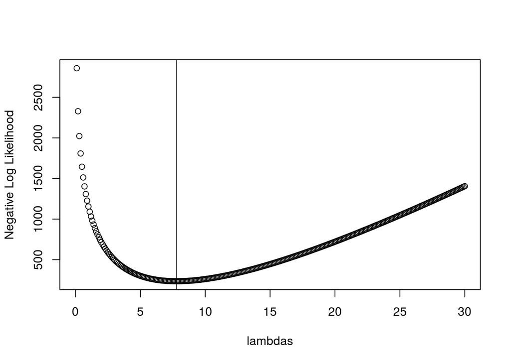

```r
plot(lambdas, negLL.vector, ylab="Negative Log Likelihood")
abline(v=MLE)
```

Interactive visualization:

```r
manipulate(plot.poisson.ll(x, lambda),
           lambda = slider(1, 20, step = 0.01))
```

# 4 Link between log likelihood and deviance

Lunn et al. (2013, p. 138) define **deviance** as:

$$D = -2 \log p(y|\theta)$$
which is two times the negative likelihood!

# 5 Link between log likelihood and AIC

Simply:

$$AIC = D + 2k$$

where $k$ is number of parameters. So for our best estimate ($\lambda = 8$), AIC will be:

```r
  AIC = 2*negLL.function(x, lambda=MLE) + 2*1
  AIC
```

```
## [1] 471.2355
```

We can compare this with the output of `glm` function:

```r
 glm(x~1, family="poisson")
```

```
##
## Call:  glm(formula = x ~ 1, family = "poisson")
##
## Coefficients:
## (Intercept)
##       2.053
##
## Degrees of Freedom: 99 Total (i.e. Null);  99 Residual
## Null Deviance:       83.72
## Residual Deviance: 83.72     AIC: 471.2
```

Note, the deviance here is different from our definition, since GLM seems to report **saturated** version of deviance (Lunn et al. 2013, p. 144)